# Final project main

Liu Peidong

2023-08-07

## Research Question

The project aims to investigate the intriguing relationship between the price of maple syrup and the average income across various states in the United States. Maple syrup, a culturally significant and economically valuable product, is known for its complex market dynamics. This study seeks to uncover whether a discernible correlation exists between maple syrup prices and the average income in different states, shedding light on potential economic and cultural factors that influence this connection.

In this project, we will analysis the relation of both data sets from two different scopes. The first case is to uncover the relation of maple syrup price in different with respect to income differed from states. The second case is to find if the relation exist for one particular state for price of syrup and income in the time span of 20 years form 2000 to 2021.

#### loading nesscessary packages

[output not shown]

## Data Processing

#### Data Intake

```r
# loading data for average maple syrup price and other information
Syrup_price <- read.file("Domestic_Maple_Syrup_Production_2000-2021.csv")
```

```
## Reading data with read.csv()
```

```r
# loading data for income of each states in 2022
web_page_states_income_2022  <- "https://fred.stlouisfed.org/release/tables?rid=110&eid=257197&od=2021-01-01#"
Income_states <- web_page_states_income_2022 %>%
  read_html() %>%
  html_nodes(css = "table") %>%
  html_table(fill = TRUE)
income_table_2021 <- Income_states[[1]]
income_table_2021 <- income_table_2021[2:3]

colnames(income_table_2021)[1] <- "State"

# loading data for median income of Michigan state from year 2000 to 2021
median_income_Michigan_2000_21 <- read.file("MEHOINUSMIA672N.csv")
```

```
## Reading data with read.csv()
```

```r
# inspect data

head(Syrup_price , n = 10)
```

```
##            State Num_of_Taps Yield_per_Tap Production Avg_Price Value
## 1          Maine        1960         0.262        514      38.6 19840
## 2       Michigan         550         0.273        150      46.3  6945
## 3  New Hampshire         530         0.240        127      64.9  8242
## 4       New York        2900         0.223        647      37.8 24457
## 5   Pennsylvania         745         0.226        168      36.2  6082
## 6        Vermont        6500         0.269       1750      32.0 56000
## 7      Wisconsin         900         0.406        365      33.1 12082
## 8          Maine        1970         0.299        590      34.9 20591
## 9       Michigan         570         0.298        170      48.6  8262
## 10 New Hampshire         530         0.291        154      52.1  8023
##    Retail_Price Wholesale_Price Bulk_P_Price Bulk_G_Price Date_Open Date_Closed
## 1          61.4           48.30         3.20        35.10 2/15/2021   4/30/2021
## 2          47.7           37.60         2.40        26.80  2/1/2021   4/14/2021
## 3          65.5           48.20         2.40        26.40 1/11/2021   4/16/2021
```

[output cut: 18 more lines]

```r
head(income_table_2021 , n = 10)
```

```
## # A tibble: 10 × 2
##    State                Dollars
##    <chr>                <chr>
##  1 Name                 2021
##  2 Alabama              49,671
##  3 Alaska               65,677
##  4 Arizona              55,574
##  5 Arkansas             50,588
##  6 California           76,800
##  7 Colorado             70,715
##  8 Connecticut          82,885
##  9 Delaware             59,846
## 10 District of Columbia 96,659
```

```r
head(median_income_Michigan_2000_21 , n = 10)
```

```
##    DATE MEHOINUSMIA672N
## 1  2000           71804
## 2  2001           69103
## 3  2002           64509
## 4  2003           66483
## 5  2004           60757
## 6  2005           63880
## 7  2006           65531
## 8  2007           64670
## 9  2008           62806
## 10 2009           58222
```

## Case 1

#### Data Wrangling

```r
# extract syrup price in each states for the year of 2021
States_Syrup_price <- Syrup_price %>%
                        distinct(State)

Syrup_price_2021 <- Syrup_price %>%
                    filter(Year == 2021) %>%
                    select(State, Avg_Price , Year)


# join tables which generates result for the average income and price of maple syrup correspond to each states. Then assign the new table as "Case_1_table" for analysis.

Case_1_table <-  States_Syrup_price %>%
                    left_join(Syrup_price_2021) %>%
                    drop_na() %>%
                    inner_join(income_table_2021 %>% rename("Income" = Dollars)) %>%
                    arrange(Income)
```

#### Date Visualization

[figure not shown]

```r
Case_1_table %>%
  ggplot(aes(x= Income , y = Avg_Price , color = State)) +
  geom_point() +
  labs(caption = "Figure #1:Income for different states with average price of maple syrup in color") +
  theme(plot.caption = element_text(size = 10 , hjust=-0.1))
```

## Case 2

#### Data Wrangling

```r
# select the data of maple syrup price only for Michigan state from 2000 to 2021
Syrup_price_Michigan <- Syrup_price %>%
  filter(grepl("Michigan", State, ignore.case = TRUE)) %>%
  select(State, Avg_Price,Year) %>%
  arrange(Year)


Case_2_table <- Syrup_price_Michigan %>%
  inner_join(median_income_Michigan_2000_21 %>%
               rename("income_median" = MEHOINUSMIA672N) %>%
               select(income_median,DATE) , by = c("Year" = "DATE")
               )
```

#### Date Visualization

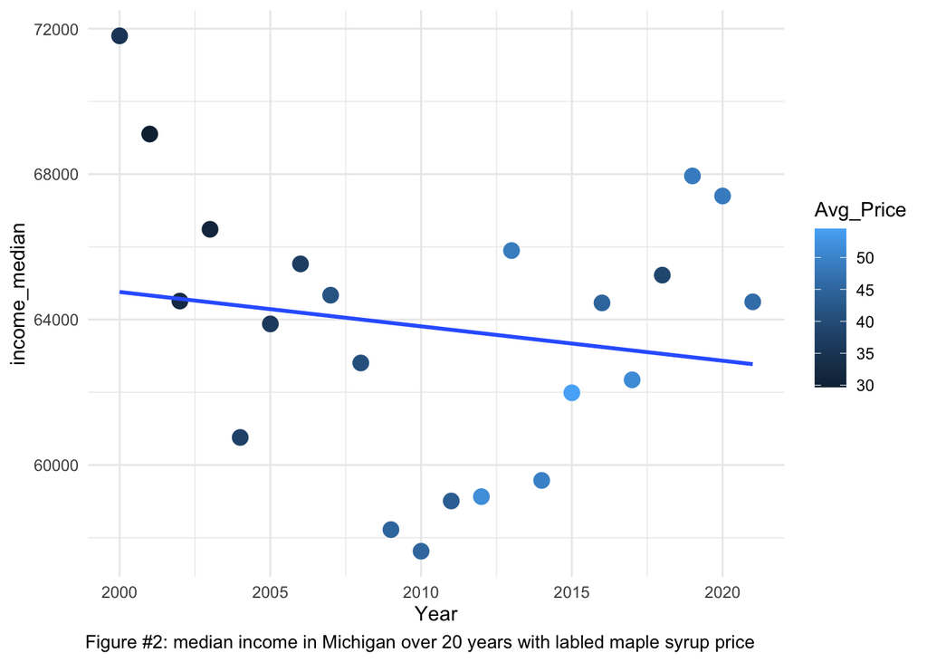

```r
ggplot(Case_2_table) +
  aes(x = Year, y = income_median, colour = Avg_Price) +
  geom_point(shape = "circle", size = 3.6) +
  scale_color_gradient() +
  theme_minimal() +
  geom_smooth(method = lm , se = FALSE) +
  labs(caption = "Figure #2: median income in Michigan over 20 years with labled maple syrup price") +
  theme(plot.caption = element_text(size = 10, hjust=-0.1))
```

## Conclusion

The relationship between the price of maple syrup across various states and their average income is generally weak, suggesting that changes in maple syrup prices don’t consistently correlate strongly with average income. However, there are instances where a trend emerges, hinting that in certain places, a higher average income might correspond to higher maple syrup prices. While this correlation isn’t universally strong, it implies that economic factors could influence maple syrup pricing, potentially leading to variations in pricing based on local economic conditions.

Over the period from 2000 to 2021, the price of maple syrup has demonstrated a relatively weak correlation with changes in the average income within a specific state. This suggests that variations in maple syrup prices over this time span have not consistently or significantly aligned with shifts in average income. Other factors beyond average income, such as production levels, market demand, supply dynamics, and external economic influences, likely play a more prominent role in driving the fluctuations in maple syrup prices within that state.

## Data Source

https://fred.stlouisfed.org/series/MEHOINUSMIA672N https://fred.stlouisfed.org/release/tables?rid=110&eid=257197&od=2021-01-01# https://www.kaggle.com/datasets/datasciencedonut/maple-syrup-production-in-the-usa-2000-2021